# 回帰不連続デザイン

Jaehyun Song

改訂: 2021-09-13

# パッケージとデータの読み込み

```r
# {pacman}パッケージがない場合
# インストールしていないパッケージはインストールしておく
# library(tidyverse) # Thanks, Hadley!
# library(haven)     # Stata形式ファイルの読み込み
# library(rdd)       # RDD推定の定番のパッケージ
# library(rdrobust)  # Local Polynomial Regressionにはこれ
# library(rddensity) # 密度検定のパッケージ

# {pacman}パッケージを予め導入しておけばらくらく！
# ないものはインストールまでしてくれるます
pacman::p_load(tidyverse, haven, rdd, rdrobust, rddensity, summarytools)
```

Stata形式ファイル (`*.dta`)は{haven}パッケージにある`read_dta()`関数を使用します。

```r
Ariga_df <- read_dta("Data/Day4_Data4.dta")
```

{summarytools}が提供する`dfSummary()`を使って`Ariga_df`の記述統計量を確認します。。R Markdownに埋め込む場合以下のようなコマンドを打ち込みますが、Rコンソール上では`view(dfSummary(Ariga_df))`と打ち込みます (もっと見やすい)。

```r
# 以下のコードはR Markdwonを使用する際に使う
Ariga_df %>%
  dfSummary(style = "grid", plain.ascii = FALSE, graph.magnif = 0.85) %>%
  print(method = "render", headings = FALSE)
```

| **No** | **Variable** | **Label** | **Stats / Values** | **Freqs (% of Valid)** | **Graph** | **Valid** | **Missing** |
| --- | --- | --- | --- | --- | --- | --- | --- |
| 1 | year [numeric] | Election Year | Mean (sd) : 2005.6 (6) min ≤ med ≤ max: 1996 ≤ 2005 ≤ 2014 IQR (CV) : 12 (0) | 1996 : 300 ( 14.3% ) 2000 : 300 ( 14.3% ) 2003 : 300 ( 14.3% ) 2005 : 300 ( 14.3% ) 2009 : 300 ( 14.3% ) 2012 : 300 ( 14.3% ) 2014 : 295 ( 14.1% ) |  | 2095 (100.0%) | 0 (0.0%) |
| 2 | prefname [character] | Prefecture Name | 1. Tokyo 2. Osaka 3. Kanagawa 4. Aichi 5. Saitama 6. Chiba 7. Hokkaido 8. Hyogo 9. Fukuoka 10. Shizuoka [ 37 others ] | 175 ( 8.4% ) 133 ( 6.3% ) 124 ( 5.9% ) 105 ( 5.0% ) 103 ( 4.9% ) 89 ( 4.2% ) 86 ( 4.1% ) 84 ( 4.0% ) 77 ( 3.7% ) 58 ( 2.8% ) 1061 ( 50.6% ) |  | 2095 (100.0%) | 0 (0.0%) |
| 3 | prefcode [numeric] | Prefecture Code | Mean (sd) : 21.4 (12.5) min ≤ med ≤ max: 1 ≤ 21 ≤ 47 IQR (CV) : 17 (0.6) | 47 distinct values |  | 2095 (100.0%) | 0 (0.0%) |
| 4 | distcode [numeric] | District Code | Mean (sd) : 2142.4 (1250.4) min ≤ med ≤ max: 101 ≤ 2103 ≤ 4704 IQR (CV) : 1697.5 (0.6) | 305 distinct values |  | 2095 (100.0%) | 0 (0.0%) |
| 5 | redist02 [numeric] | 2002 Redistricting Code | Mean (sd) : 0.1 (0.3) min ≤ med ≤ max: 0 ≤ 0 ≤ 5 IQR (CV) : 0 (6.3) | 0 : 2034 ( 97.1% ) 1 : 17 ( 0.8% ) 2 : 37 ( 1.8% ) 3 : 5 ( 0.2% ) 5 : 2 ( 0.1% ) |  | 2095 (100.0%) | 0 (0.0%) |
| 6 | redist13 [numeric] | 2013 Redistricting Code | Mean (sd) : 0 (0.2) min ≤ med ≤ max: 0 ≤ 0 ≤ 2 IQR (CV) : 0 (7.9) | 0 : 2058 ( 98.2% ) 1 : 27 ( 1.3% ) 2 : 10 ( 0.5% ) |  | 2095 (100.0%) | 0 (0.0%) |
| 7 | totcand [numeric] | Total Number of Candidates | Mean (sd) : 3.8 (1) min ≤ med ≤ max: 2 ≤ 4 ≤ 9 IQR (CV) : 1 (0.3) | 2 : 71 ( 3.4% ) 3 : 924 ( 44.1% ) 4 : 691 ( 33.0% ) 5 : 297 ( 14.2% ) 6 : 88 ( 4.2% ) 7 : 18 ( 0.9% ) 8 : 4 ( 0.2% ) 9 : 2 ( 0.1% ) |  | 2095 (100.0%) | 0 (0.0%) |
| 8 | encand [numeric] | Effective Number of Candidates | Mean (sd) : 2.6 (0.6) min ≤ med ≤ max: 1.1 ≤ 2.4 ≤ 6.9 IQR (CV) : 0.8 (0.2) | 2095 distinct values |  | 2095 (100.0%) | 0 (0.0%) |
| 9 | tvotes [numeric] | Total Number of Votes | Mean (sd) : 204356.8 (41826.3) min ≤ med ≤ max: 104175 ≤ 203381 ≤ 339780 IQR (CV) : 58615 (0.2) | 2077 distinct values |  | 2095 (100.0%) | 0 (0.0%) |
| 10 | ldpv_smd [numeric] | LDP Vote Share in SMD | Mean (sd) : 46 (12.4) min ≤ med ≤ max: 10.4 ≤ 45.1 ≤ 84.8 IQR (CV) : 16.1 (0.3) | 1987 distinct values |  | 1987 (94.8%) | 108 (5.2%) |
| 11 | ldpv_pr [numeric] | LDP Vote Share in PR | Mean (sd) : 31.9 (7.4) min ≤ med ≤ max: 0.4 ≤ 31.7 ≤ 55.7 IQR (CV) : 10.7 (0.2) | 1806 distinct values |  | 2095 (100.0%) | 0 (0.0%) |
| 12 | dual_1 [numeric] | LDP: Dual Candidacy Status | Min : 0 Mean : 0.9 Max : 1 | 0 : 114 ( 5.7% ) 1 : 1873 ( 94.3% ) |  | 1987 (94.8%) | 108 (5.2%) |
| 13 | win_1 [numeric] | LDP: Results | Mean (sd) : 1.4 (0.8) min ≤ med ≤ max: 0 ≤ 2 ≤ 2 IQR (CV) : 1 (0.6) | 0 : 470 ( 23.7% ) 1 : 261 ( 13.1% ) 2 : 1256 ( 63.2% ) |  | 1987 (94.8%) | 108 (5.2%) |
| 14 | inc_1 [numeric] | LDP: Incumbency Dummy | Min : 0 Mean : 0.7 Max : 1 | 0 : 613 ( 30.9% ) 1 : 1374 ( 69.1% ) |  | 1987 (94.8%) | 108 (5.2%) |
| 15 | votes_1 [numeric] | LDP: Votes | Mean (sd) : 92499.4 (26598.1) min ≤ med ≤ max: 16407 ≤ 91222 ≤ 197037 IQR (CV) : 35818.5 (0.3) | 1966 distinct values |  | 1987 (94.8%) | 108 (5.2%) |
| 16 | party_0 [numeric] | non-LDP: Party Code | Mean (sd) : 11.6 (23.5) min ≤ med ≤ max: 2 ≤ 2 ≤ 99 IQR (CV) : 8 (2) | 23 distinct values |  | 2095 (100.0%) | 0 (0.0%) |
| 17 | dual_0 [numeric] | non-LDP: Dual Candidacy Status | Min : 0 Mean : 0.8 Max : 1 | 0 : 472 ( 22.5% ) 1 : 1623 ( 77.5% ) |  | 2095 (100.0%) | 0 (0.0%) |
| 18 | win_0 [numeric] | non-LDP: Results | Mean (sd) : 1 (0.9) min ≤ med ≤ max: 0 ≤ 1 ≤ 2 IQR (CV) : 2 (1) | 0 : 922 ( 44.0% ) 1 : 334 ( 15.9% ) 2 : 839 ( 40.0% ) |  | 2095 (100.0%) | 0 (0.0%) |
| 19 | inc_0 [numeric] | non-LDP: Incumbency Dummy | Min : 0 Mean : 0.5 Max : 1 | 0 : 1043 ( 49.8% ) 1 : 1052 ( 50.2% ) |  | 2095 (100.0%) | 0 (0.0%) |
| 20 | votes_0 [numeric] | Non-LDP: Votes | Mean (sd) : 79815.9 (31730.3) min ≤ med ≤ max: 16576 ≤ 76031 ≤ 201461 IQR (CV) : 42734.5 (0.4) | 2074 distinct values |  | 2095 (100.0%) | 0 (0.0%) |
| 21 | year2 [numeric] |  | Mean (sd) : 4 (2) min ≤ med ≤ max: 1 ≤ 4 ≤ 7 IQR (CV) : 4 (0.5) | 1 : 300 ( 14.3% ) 2 : 300 ( 14.3% ) 3 : 300 ( 14.3% ) 4 : 300 ( 14.3% ) 5 : 300 ( 14.3% ) 6 : 300 ( 14.3% ) 7 : 295 ( 14.1% ) |  | 2095 (100.0%) | 0 (0.0%) |
| 22 | vm1 [numeric] |  | Mean (sd) : 4 (10.2) min ≤ med ≤ max: -27.1 ≤ 3.4 ≤ 36.3 IQR (CV) : 13 (2.6) | 1987 distinct values |  | 1987 (94.8%) | 108 (5.2%) |
| 23 | F_ldpv_smd [numeric] | LDP Vote Share in SMD at t+1 | Mean (sd) : 46.8 (11.9) min ≤ med ≤ max: 13.3 ≤ 46 ≤ 84.5 IQR (CV) : 15.1 (0.3) | 1694 distinct values |  | 1694 (80.9%) | 401 (19.1%) |
| 24 | F_ldpv_pr [numeric] | LDP Vote Share in PR at t+1 | Mean (sd) : 31.8 (7) min ≤ med ≤ max: 11.1 ≤ 31.7 ≤ 54.4 IQR (CV) : 10.4 (0.2) | 1503 distinct values |  | 1790 (85.4%) | 305 (14.6%) |
| 25 | F_ldpwin_smd [numeric] | LDP Victory in SMD at t+1 | Min : 0 Mean : 0.6 Max : 1 | 0 : 610 ( 36.0% ) 1 : 1084 ( 64.0% ) |  | 1694 (80.9%) | 401 (19.1%) |
| 26 | F_ldpwin_zmb [numeric] | LDP Resurrected in PR (Hirei Fukkatsu) at t+1 | Min : 0 Mean : 0.1 Max : 1 | 0 : 1466 ( 86.5% ) 1 : 228 ( 13.5% ) |  | 1694 (80.9%) | 401 (19.1%) |
| 27 | L_vm1 [numeric] | Vote Margin (SMD) in Election at t-1 | Mean (sd) : 3.3 (10.1) min ≤ med ≤ max: -27.1 ≤ 2.7 ≤ 36.3 IQR (CV) : 13 (3.1) | 1694 distinct values |  | 1694 (80.9%) | 401 (19.1%) |
| 28 | L_ldpv_smd [numeric] | LDP Vote Share in SMD at t-1 | Mean (sd) : 45.1 (12.2) min ≤ med ≤ max: 10.4 ≤ 44.2 ≤ 84.8 IQR (CV) : 16.5 (0.3) | 1694 distinct values |  | 1694 (80.9%) | 401 (19.1%) |
| 29 | L_ldpv_pr [numeric] | LDP Vote Share in PR at t-1 | Mean (sd) : 31.6 (7.7) min ≤ med ≤ max: 0.4 ≤ 31.1 ≤ 55.7 IQR (CV) : 11.6 (0.2) | 1501 distinct values |  | 1790 (85.4%) | 305 (14.6%) |
| 30 | L_ldpwin_smd [numeric] | LDP Victory in SMD at t-1 | Min : 0 Mean : 0.6 Max : 1 | 0 : 667 ( 39.4% ) 1 : 1027 ( 60.6% ) |  | 1694 (80.9%) | 401 (19.1%) |
| 31 | L_ldpwin_zmb [numeric] | LDP Resurrected in PR (Hirei Lukkatsu) at t-1 | Min : 0 Mean : 0.1 Max : 1 | 0 : 1486 ( 87.7% ) 1 : 208 ( 12.3% ) |  | 1694 (80.9%) | 401 (19.1%) |
| 32 | L_totcand [numeric] | Total Number of Candidates (SMD) in Election at t-1 | Mean (sd) : 3.8 (1) min ≤ med ≤ max: 2 ≤ 4 ≤ 9 IQR (CV) : 1 (0.3) | 2 : 37 ( 2.1% ) 3 : 743 ( 41.5% ) 4 : 620 ( 34.6% ) 5 : 282 ( 15.8% ) 6 : 84 ( 4.7% ) 7 : 18 ( 1.0% ) 8 : 4 ( 0.2% ) 9 : 2 ( 0.1% ) |  | 1790 (85.4%) | 305 (14.6%) |
| 33 | L_encand [numeric] | Effective Number of Candidates (SMD) in Election at t-1 | Mean (sd) : 2.6 (0.6) min ≤ med ≤ max: 1.1 ≤ 2.4 ≤ 6.9 IQR (CV) : 0.8 (0.2) | 1790 distinct values |  | 1790 (85.4%) | 305 (14.6%) |
| 34 | ldpwin_smd_zmb [numeric] | LDP Victory in SMD or Resurrected in PR at t | Min : 0 Mean : 0.8 Max : 1 | 0 : 470 ( 22.4% ) 1 : 1625 ( 77.6% ) |  | 2095 (100.0%) | 0 (0.0%) |
| 35 | nonldpwin_smd_zmb [numeric] | non LDP Victory in SMD or Resurrected in PR at t | Min : 0 Mean : 0.6 Max : 1 | 0 : 922 ( 44.0% ) 1 : 1173 ( 56.0% ) |  | 2095 (100.0%) | 0 (0.0%) |
| 36 | F_totcand [numeric] | Total Number of Candidates (SMD) in Election at t+1 | Mean (sd) : 3.7 (0.9) min ≤ med ≤ max: 2 ≤ 3 ≤ 9 IQR (CV) : 1 (0.3) | 2 : 67 ( 3.7% ) 3 : 838 ( 46.8% ) 4 : 577 ( 32.2% ) 5 : 235 ( 13.1% ) 6 : 62 ( 3.5% ) 7 : 8 ( 0.4% ) 8 : 1 ( 0.1% ) 9 : 2 ( 0.1% ) |  | 1790 (85.4%) | 305 (14.6%) |
| 37 | F_encand [numeric] | Effective Number of Candidates (SMD) in Election at t+1 | Mean (sd) : 2.5 (0.6) min ≤ med ≤ max: 1.1 ≤ 2.4 ≤ 5.4 IQR (CV) : 0.7 (0.2) | 1790 distinct values |  | 1790 (85.4%) | 305 (14.6%) |
| 38 | F_redist02 [numeric] |  | Mean (sd) : 0.1 (0.3) min ≤ med ≤ max: 0 ≤ 0 ≤ 5 IQR (CV) : 0 (6.1) | 0 : 1734 ( 96.9% ) 1 : 17 ( 0.9% ) 2 : 37 ( 2.1% ) 5 : 2 ( 0.1% ) |  | 1790 (85.4%) | 305 (14.6%) |
| 39 | F_redist13 [numeric] |  | Mean (sd) : 0 (0.2) min ≤ med ≤ max: 0 ≤ 0 ≤ 2 IQR (CV) : 0 (7.3) | 0 : 1753 ( 97.9% ) 1 : 27 ( 1.5% ) 2 : 10 ( 0.6% ) |  | 1790 (85.4%) | 305 (14.6%) |
| 40 | ldp_LCF [numeric] | Districts with no boundary change in which LDP Ran in t-1, t & t+1 | Min : 0 Mean : 0.6 Max : 1 | 0 : 829 ( 39.6% ) 1 : 1266 ( 60.4% ) |  | 2095 (100.0%) | 0 (0.0%) |

Generated by summarytools 1.0.0 ([R](https://www.r-project.org/) version 4.1.1)  
2021-09-13

# とりあえず、処置効果の推定

早速ですが、RDDをやってみましょう。その前にt-1期からt+1期間、区割りの変更がなかった選挙区のみに絞りましょう。`ldp_LCF`変数が1なら変更なし、0なら変化ありの選挙区です。ここでは{dplyr}の`filter()`関数を使用し、`ldp_LCF`の値が1である行のみを抽出し、`Ariga_df`に上書きします。

```r
# t-1 ~ t+1期において境界が変化していない選挙区のみ抽出
Ariga_df <- Ariga_df %>%
    filter(ldp_LCF == 1)
```

因果効果の推定は{rdd}パッケージにある`RDestimate()`関数を使います。このパッケージは自動的に最適バンド幅を設定し[^1]、**交差項**が含まれた局所**線形**回帰分析を行った結果を返してくれます[^2]。また、デフォルトのカーネルは三角 (triangular)カーネル関数です。

`RDestimate()`の基本的な使い方は`RDestimate(結果変数 ~ 強制変数, data = ...)`です。

```r
# 因果効果の推定
Ariga_RDD <- RDestimate(F_ldpv_smd ~ vm1, data = Ariga_df,
                        cutpoint = 0,
                        model = TRUE, frame = TRUE)

summary(Ariga_RDD)
```

```
##
## Call:
## RDestimate(formula = F_ldpv_smd ~ vm1, data = Ariga_df, cutpoint = 0,
##     model = TRUE, frame = TRUE)
##
## Type:
## sharp
##
## Estimates:
##            Bandwidth  Observations  Estimate  Std. Error  z value  Pr(>|z|)
## LATE        7.424      647          0.62764   1.668       0.3762   0.7068
## Half-BW     3.712      339          0.28247   2.364       0.1195   0.9049
## Double-BW  14.848     1059          0.09611   1.188       0.0809   0.9355
## ---
## Signif. codes:  0 '***' 0.001 '**' 0.01 '*' 0.05 '.' 0.1 ' ' 1
##
## F-statistics:
##            F       Num. DoF  Denom. DoF  p
## LATE        6.704  3          643        0.00037
## Half-BW     1.079  3          335        0.71602
## Double-BW  38.748  3         1055        0.00000
```

最適バンド幅 (Imbens-Kalyanaraman Optimal Bandwidth)は7.424であり、処置効果は約0.628です。自民党候補者の投票率から非自民候補者の最高得票率を引いた値（`vm1`）が-7.424から7.424までのデータを使うことを意味します。そして、これらのデータに対して交差項が含まれる線形回帰分析を行うことになります。また、閾値周辺に重みを付けるために三角カーネル関数による重み付けを行いました。

`LATE`行は最適バンド幅の場合の推定結果であり、`Half-BW`と`Double-BW`はバンド幅を最適バンド幅より0.5倍、2倍にした場合の因果効果です。いずれの場合も、**統計的**に有意な現職効果は確認できません。

## `RDestimate()`を使わない方法

以上は全ての計算を`RDestimate()`関数に任せた結果ですが、この関数を仕組を理解するために、私たちで直接計算をしてみましょう。バンド幅の計算は非常に面倒な作業ですので、これだけは{rdd}パッケージに含まれている`IKbandwidth()`関数を使います。使い方は結果変数と強制変数をそれぞれ`Y`、`X`引数と指定します。つづて閾値ですが、今回は`cutpoint = 0`とします。また、重み付けの関数は三角形関数であるため、`kernel = "triangular"`とします。

```r
Ariga_bw <- IKbandwidth(Y = Ariga_df$F_ldpv_smd, X = Ariga_df$vm1,
                        cutpoint = 0, kernel = "triangular")

Ariga_bw
```

```
## [1] 7.423955
```

7.4239549の結果が実際、`RDestimate()`から得られたLATEのバンド幅と一致します。それでは、データを用意します。まずは、使用する変数は`F_ldpv_smd`と`vm1`のみですから、この2列だけを残し、`vm1`がバンド幅内に位置する行のみ残します。もし、`select()`関数でエラーが出る場合、`dplyr::select()`を使用してください。今回の例では問題ございませんが、Rのメジャーなパッケージの一つである{MASS}にも`select()`関数があります。もし、{tidyverse}（あるいは{dplyr}）の後に{MASS}を読み込んだ場合、`select()`関数は`MASS::select()`を意味します。その意味で`select()`関数はパッケージ名も指定した方が良いかも知れませんね。

```r
Ariga_df2 <- Ariga_df %>%
  # F_ldpv_smd、vm1列のみ残す
  select(F_ldpv_smd, vm1) %>%
  # vm1が-1 * Ariga_bw以上、Ariga_bw以下のケースに絞る
  filter(vm1 <= Ariga_bw & vm1 >= -1 * Ariga_bw)

Ariga_df2
```

```
## # A tibble: 647 × 2
##    F_ldpv_smd    vm1
##         <dbl>  <dbl>
##  1       36.8 -2.45
##  2       39.6  1.09
##  3       35.3  2.52
##  4       44.5 -5.13
##  5       30.8 -0.407
##  6       38.8  5.87
##  7       45.6 -1.25
##  8       48.4 -0.590
##  9       36.9  2.32
## 10       39.5  4.96
## # … with 637 more rows
```

データの大きさは647行2列です。この647ですが、`RDestimate()`から得られたLATE推定値の観察数（Observations）と一致することが分かります。それでは続きまして、重み付け変数を作成します。三角形関数による重み付けは比較的簡単です。

$$\frac{1 - |強制変数の値 / 最適バンド幅|}{\sum (1 - |強制変数の値 / 最適バンド幅|)}$$

```r
Ariga_df2 <- Ariga_df2 %>%
  mutate(W = 1 - abs(vm1 / Ariga_bw),
         W = W / sum(W))

Ariga_df2
```

```
## # A tibble: 647 × 3
##    F_ldpv_smd    vm1        W
##         <dbl>  <dbl>    <dbl>
##  1       36.8 -2.45  0.00200
##  2       39.6  1.09  0.00255
##  3       35.3  2.52  0.00197
##  4       44.5 -5.13  0.000921
##  5       30.8 -0.407 0.00282
##  6       38.8  5.87  0.000625
##  7       45.6 -1.25  0.00248
##  8       48.4 -0.590 0.00275
##  9       36.9  2.32  0.00205
## 10       39.5  4.96  0.000991
## # … with 637 more rows
```

ちゃんと重み付け変数が作成されたかを可視化してみましょう。具体的には横軸が`vm1`、縦軸が`W`の散布図を作成します。閾値（`vm1 == 0`）で`W`が最大値となり、全ての`W`が正ならOKです。

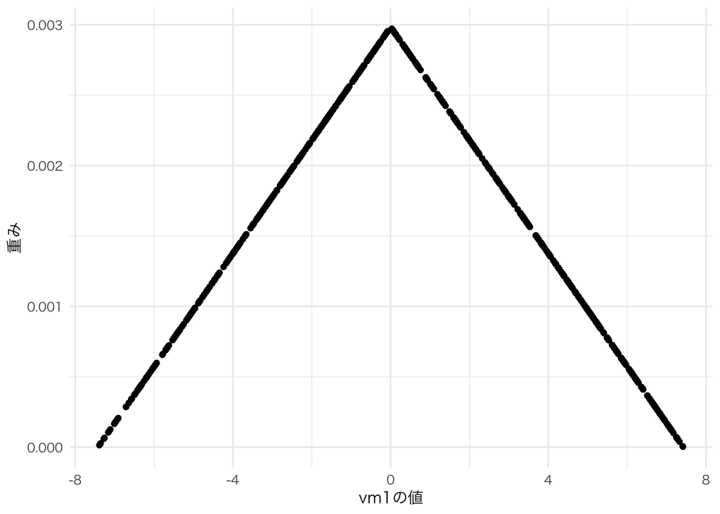

```r
Ariga_df2 %>%
  ggplot(aes(x = vm1, y = W)) +
  geom_point() +
  labs(x = "vm1の値", y = "重み") +
  theme_minimal(base_family = "HiraKakuProN-W3")
```

バッチリですね。それでは重み付け回帰分析を行います。投入する変数は強制変数（`vm1`）と強制変数が閾値以上か否かを示すダミー変数、そして2つの交差項です。ダミー変数は式中に`I(vm1 >= 0)`を入れることで簡単に作成することが可能です。そして、2つの変数を`+`でなく`*`で繋ぐと、自動的に主効果と交差項が投入されます。そして`weights = W`を指定し、`W`の値に応じて重み付けます。

```r
Ariga_Fit1 <- lm(F_ldpv_smd ~ vm1 * I(vm1 >= 0),
                 data = Ariga_df2, weights = W)

summary(Ariga_Fit1)
```

```
##
## Call:
## lm(formula = F_ldpv_smd ~ vm1 * I(vm1 >= 0), data = Ariga_df2,
##     weights = W)
##
## Weighted Residuals:
##      Min       1Q   Median       3Q      Max
## -1.70733 -0.21036 -0.00695  0.21099  1.51911
##
## Coefficients:
##                     Estimate Std. Error t value Pr(>|t|)
## (Intercept)         43.93436    0.89231  49.236   <2e-16
## vm1                  0.47522    0.31661   1.501    0.134
## I(vm1 >= 0)TRUE      0.62764    1.25710   0.499    0.618
## vm1:I(vm1 >= 0)TRUE -0.03011    0.42391  -0.071    0.943
##
## Residual standard error: 0.3645 on 643 degrees of freedom
## Multiple R-squared:  0.03033,    Adjusted R-squared:  0.02581
## F-statistic: 6.704 on 3 and 643 DF,  p-value: 0.000185
```

`I(vm1 >= 0)TRUE`の係数が0.6276412であり、`RDestimate()`から得られたLATE推定値と一致することが分かります。これで`RDestimate()`関数の仕組みが理解出来たでしょう。

# 散布図 de 可視化

RDDは推定より、可視化の方が楽しいです。まずは定番の散布図 + 回帰直線から作図してみましょう。

普通の回帰分析で良いですが、`vm1`変数が0より大きい場合に1を、以下の場合は0にした変数を投入する必要があります。これは回帰式に`I(vm1 > 0)`を投入するだけで解決できます。

`I()`は指示関数 (indicator function)であり、カッコ内の条件を満たせれば`1`を、その他の場合は`0`を返します。たとえば、`I(3 < 0)`の結果は`FALSE`であり、`I(3 < 5)`の結果は`TRUE`です。Rの場合、`TRUE`は1、`FALSE`は0と解釈します。

```r
## (1) Full Cases with Regression line
Ariga_lm <- lm(F_ldpv_smd ~ vm1 * I(vm1 > 0),
               data = Ariga_df)
```

次は回帰直線を引くための予測値を計算します。ここれでは、強制変数を`min(vm1)`から`max(vm1)`まで変化させた場合の予測値を計算してみたいと思います。予測値は強制変数を200区間刻みで計算します。

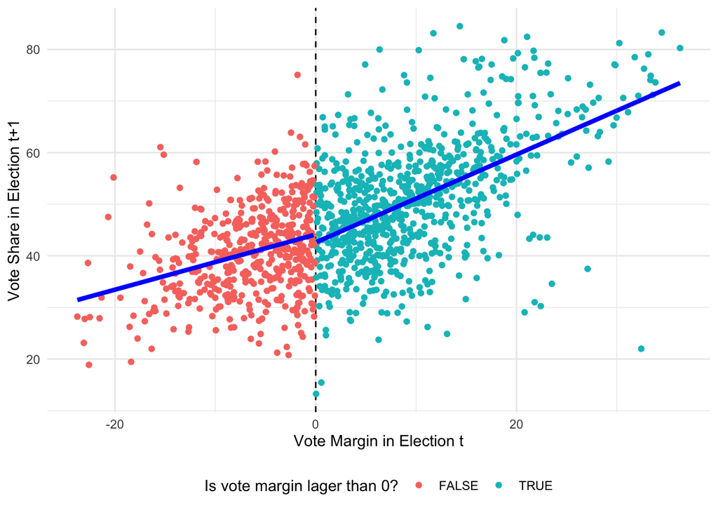

```r
# 強制変数を最小値から最大値まで200区間刻みに
Pred_X     <- seq(min(Ariga_df$vm1), max(Ariga_df$vm1),
                  length = 200)

# 予測値 (予測得票率)の計算
Ariga_Pred <- predict(Ariga_lm,
                      newdata = data.frame(vm1 = Pred_X))

# 予測値を格納したデータフレームを作成
Pred_df <- data.frame(vm1  = Pred_X,
                      Pred = Ariga_Pred)

Ariga_df %>% ggplot() +
    # まずは閾値に垂直線
    geom_vline(xintercept = 0, linetype = 2) +
    # 散布図。vm1が0より大きいか否かで色を区分
    geom_point(aes(x = vm1, y = F_ldpv_smd, color = (vm1 > 0))) +
    # vm1が0以下の場合の回帰直線
    geom_line(data = filter(Pred_df, vm1 <= 0),
              aes(x = vm1, y = Pred), color = "blue", size = 1.5) +
    # vm1が0より大きい場合の回帰直線
    geom_line(data = filter(Pred_df, vm1 > 0),
              aes(x = vm1, y = Pred), color = "blue", size = 1.5) +
    labs(x = "Vote Margin in Election t",
         y = "Vote Share in Election t+1",
         color = "Is vote margin lager than 0?") +
    theme_minimal() +
    theme(legend.position = "bottom")
```

つづいて、論文のFigure 2 (a)のような図を作ってみます[^3]。これは$-15 \leq \textrm{vm1} \leq 15$の範囲内を対象にした散布図ですが、全ての点を表示させたものではなく、`vm1`を0.5単位で区切りし、その区間内の平均値を出したものです。

```r
# -15 <= vm1 <= 15のデータのみを抽出し、Ariga_df2で保存
Ariga_df2 <- Ariga_df %>%
    filter(vm1 >= -15, vm1 <= 15)
```

続いて、歴史を、いや、`vm1`変数を0.5単位で刻みます。ここでは`cut()`関数を使います。第一引数は刻む変数名、第二引数は区間を指定したベクトルです。`seq(-15, 15, 0.5)`は`c(-15, -14.5, -14, -13.5, ..., 14, 14.5, 15)`と同じ意味です。

```r
# vm1を-15から15の間で0.5単位で区切る
Ariga_df2 <- Ariga_df2 %>%
    mutate(cut  = cut(vm1, breaks = seq(-15, 15, 0.5)),
           # 区切った結果はfactor型なので数値型(numeric)に
           cut2 = as.numeric(cut)) %>%
    # 3つの変数だけ残す
    select(F_ldpv_smd, cut, cut2, vm1)

# 中身を確認
head(Ariga_df2)
```

```
## # A tibble: 6 × 4
##   F_ldpv_smd cut          cut2    vm1
##        <dbl> <fct>       <dbl>  <dbl>
## 1       34.6 (-11,-10.5]     9 -10.8
## 2       40.8 (-10.5,-10]    10 -10.4
## 3       36.8 (-2.5,-2]      26  -2.45
## 4       31.1 (-9,-8.5]      13  -8.72
## 5       39.6 (1,1.5]        33   1.09
## 6       35.3 (2.5,3]        36   2.52
```

区切りは問題ないんですが、factor型をnumeric型に変換することでX軸の情報が無くなりました。たとえば、`(-15, -14.5]`は1になり、`(-14.5, -14]`は2になりましたよね。これを`(-15, -14.5]`は-14.75、`(-14.5, -14]`は-14.25などにしたいですね。

これは元の数値から30.5を引いて、2で割ると計算できます。たとえば`(-14.5, -14]`は2なので、$\frac{2 - 30.5}{2} = \frac{-28.5}{2} = -14.25$となります。

```r
# スケール調整
Ariga_df2 <- Ariga_df2 %>%
    mutate(cut2 = (cut2 - 30.5) / 2)
```

次は`cut2`変数ごとにグループ化し、t+1期の自民党候補者の得票率 (`F_ldpv_smd`)の平均値を計算します。

```r
Ariga_Fig2a_df <- Ariga_df2 %>%
    group_by(cut2) %>%
    summarise(Vote = mean(F_ldpv_smd, na.rm = TRUE),
              .groups = "drop")

# 中身を確認
head(Ariga_Fig2a_df)
```

```
## # A tibble: 6 × 2
##    cut2  Vote
##   <dbl> <dbl>
## 1 -14.8  35.3
## 2 -14.2  34.2
## 3 -13.8  37.2
## 4 -13.2  37.7
## 5 -12.8  30.8
## 6 -12.2  41.1
```

いよいよ作図の時間です。

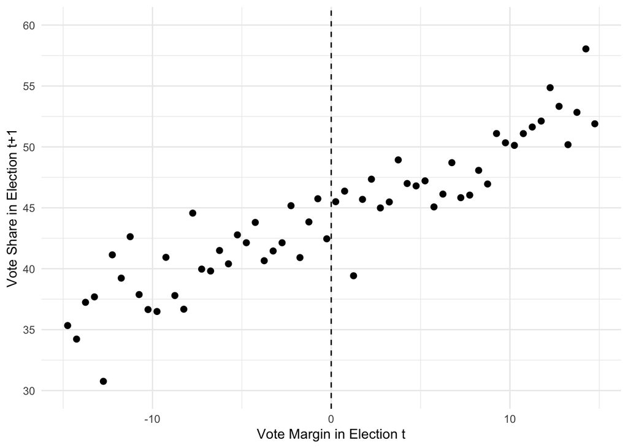

```r
Ariga_Fig2a_df %>%
    ggplot() +
    # まずcutoffに垂直線
    geom_vline(xintercept = 0, linetype = 2) +
    # 点をプロット
    geom_point(aes(x = cut2, y = Vote), size = 2) +
    # y軸のtickを指定
    scale_y_continuous(breaks = seq(30, 60, 5),
                       labels = seq(30, 60, 5)) +
    # y軸の最小値と最大値を設定
    coord_cartesian(ylim = c(30, 60)) +
    labs(x = "Vote Margin in Election t",
         y = "Vote Share in Election t+1") +
    theme_minimal()
```

# 処置効果の可視化

以下の図は、実は論文ではあまり見ないものです。ただし、感度分析の可視化の練習にもなるので、最適バンド幅、それ半分にした場合、2倍にした場合の処置効果をエラーバー付きで可視化します。

処置交換の点推定値は`RDD推定結果のオブジェクト名$est`から抽出できます。また、標準誤差は`$se`で抽出します。95%信頼区間は(推定値 $\pm$ 標準正規分布の下側97.5%の点 $\times$ 標準誤差)で求めることが出来ます[^4]。

```r
# Causal Effectの表示
## Optimal BW, Half BW, Double BW
Ariga_Est <- Ariga_RDD$est
Ariga_UL  <- Ariga_Est + qnorm(0.975) * Ariga_RDD$se
Ariga_LL  <- Ariga_Est - qnorm(0.975) * Ariga_RDD$se
```

推定値、95%信頼区間、各推定値のラベルを格納したデータフレーム、`Ariga_Est_df`を作成します。また、図の横軸の順番を固定するために、ラベル変数はfactor化します。

```r
Ariga_Est_df <- data.frame(BW  = c("Optimal", "Half", "Double"),
                           Est = Ariga_Est,
                           LL  = Ariga_LL,
                           UL  = Ariga_UL)

# このまま作図すると横軸がDouble-Half-Lateになるので、
# Optimal, Half, Doubleになるように順序付きのfactor型へ
Ariga_Est_df$BW <- factor(Ariga_Est_df$BW,
                          ordered = TRUE,
                          levels = c("Optimal", "Half", "Double"))
```

可視化の時間です！ちなみにy軸ラベルにある`\n`は改行を意味します。

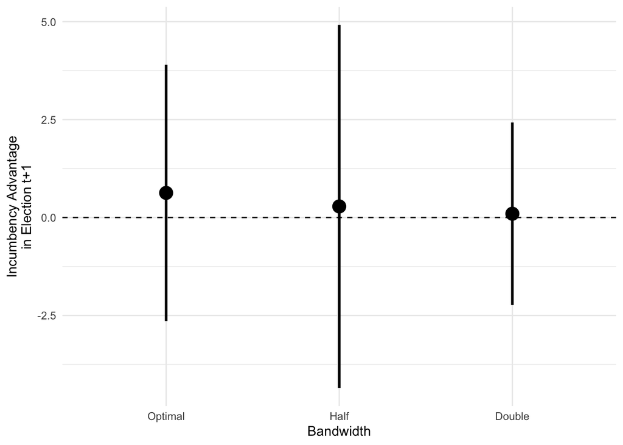

```r
Ariga_Est_df %>%
    ggplot() +
    geom_hline(yintercept = 0, linetype = 2) +
    geom_pointrange(aes(x = BW, y = Est, ymin = LL, ymax = UL),
                    size = 1) +
    labs(x = "Bandwidth",
         y = "Incumbency Advantage\nin Election t+1") +
    theme_minimal()
```

# 頑健性の確認：感度分析

続いて、RDD推定値の頑健性 (robustness)を示すために感度分析 (Sensitivity analysis)を行い、可視化します。これは推定モデルを変えることで推定値がどのように変化するかを確認する手法です。推定モデルが多少変わっても推定値に大きな変化がない場合、推定値は頑健だと言えるでしょう。逆に、モデルの小さな変化でも推定値が大きく変わったら、推定値の信頼性は低くなります。

まずは、バンド幅を3から20まで動かしながら、推定値の変化を観察してみましょう。

そのためには各バンド幅に対応した推定値と信頼区間を格納するデータフレームが必要なので、`Sensitivity_BW`という名前で作っておきます。

```r
## (1) BWを3から20まで動かしながらCausal Effectを表示
Sensitivity_BW <- data.frame(BW  = 3:20,
                             Est = rep(NA, 18),
                             LL  = rep(NA, 18),
                             UL  = rep(NA, 18))
```

バンド幅を3から20まで (1単位ずつ)変化させるということは、18回のRDDを推定する必要があるということです。反復作業は{purrr}の`map()`などを使った方がスマートですが、ここでは`for()`文を使用します。`for()`文の使い方は[『私たちのR』第11.3章](https://www.jaysong.net/RBook/programming.html#programming-iteration)を参照してください。

```r
for (i in 1:18) { # 18回反復。iを1から18まで漸増させる。
    # 臨時オブジェクト (Temp_RDD)にRDD結果を格納
    # バンド幅は最適幅ではなく、i+2に固定
    # つまり、最初のループではi = 1であるため、バンド幅は3
    Temp_RDD <- RDestimate(F_ldpv_smd ~ vm1, bw = i + 2,
                           data = Ariga_df)

    Temp_Est <- Temp_RDD$est[1] # 点推定値
    Temp_SE  <- Temp_RDD$se[1]  # 標準誤差

    # バンド幅、点推定値、信頼区間を格納
    Sensitivity_BW[i, ] <- c(i + 2,
                             Temp_Est,
                             Temp_Est - qnorm(0.975) * Temp_SE,
                             Temp_Est + qnorm(0.975) * Temp_SE)
}
```

楽しい可視化の時間が帰ってきました。

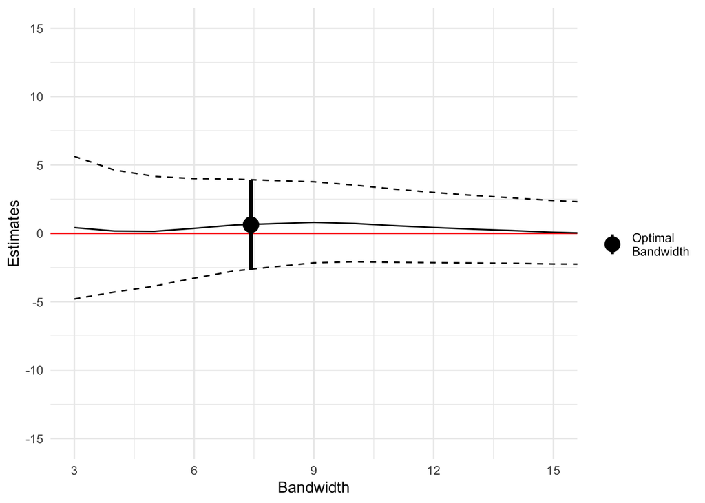

```r
Sensitivity_BW %>% ggplot() +
    # まず、y = 0の水平線を引く
    geom_hline(yintercept = 0, color = "red") +
    # 点推定値の線
    geom_line(aes(x = BW, y = Est)) +
    # 95% 信頼区間 (上限)
    geom_line(aes(x = BW, y = UL), linetype = 2) +
    # 95% 信頼区間 (下限)
    geom_line(aes(x = BW, y = LL), linetype = 2) +
    # 最適バンド幅での推定値と信頼区間は特別にお示しましょう。
    geom_pointrange(aes(x = Ariga_RDD$bw[1], y = Ariga_RDD$est[1],
                        ymin = Ariga_RDD$est[1] - qnorm(0.975) * Ariga_RDD$se[1],
                        ymax = Ariga_RDD$est[1] + qnorm(0.975) * Ariga_RDD$se[1],
                        color = "Optimal\nBandwidth"),
                    size = 1) +
    scale_color_manual(values = c("Optimal\nBandwidth" = "black")) +
    labs(x = "Bandwidth", y = "Estimates", color = "") +
    coord_cartesian(ylim = c(-15, 15), xlim = c(3, 15)) +
    scale_x_continuous(breaks = seq(3, 15, 3),
                       labels = seq(3, 15, 3)) +
    scale_y_continuous(breaks = seq(-15, 15, 5),
                       labels = seq(-15, 15, 5)) +
    theme_minimal()
```

次は、バンド幅は最適幅に固定した上で、局所多項式回帰で推定した結果を示します。もし、最高次数によって推定結果が大きく変動すると推定値の信頼性が低いことを意味しますね。局所多項式回帰を用いたノンパラメトリック推定は、{rdrobust}パッケージ内の`rdrobust()`関数を使います。このパッケージは最適バンド幅をImbens-Kalyanaraman最適バンド幅ではなく、Calonico-Cattaneo-Titiunik (CCT)最適バンド幅を使うので、`RDestimate()`で推定されたバンド幅を使います[^5]。

`rdrobust()`の使い方は`rdroubst(y = 結果変数, y = 強制変数, p = 最高次数, h = バンド幅)`です。`h`を指定しないと、CCT最適バンド幅が選択されます。また、`c = ...`で閾値の設定も可能です。

```r
## (2) Local Polynomial Regression with Optimal Bandwidth
Ariga_Poly1 <- rdrobust(y = Ariga_df$F_ldpv_smd,
                        x = Ariga_df$vm1,
                        p = 1, h = Ariga_RDD$bw[1])
Ariga_Poly2 <- rdrobust(y = Ariga_df$F_ldpv_smd,
                        x = Ariga_df$vm1,
                        p = 2, h = Ariga_RDD$bw[1])
Ariga_Poly3 <- rdrobust(y = Ariga_df$F_ldpv_smd,
                        x = Ariga_df$vm1,
                        p = 3, h = Ariga_RDD$bw[1])
Ariga_Poly4 <- rdrobust(y = Ariga_df$F_ldpv_smd,
                        x = Ariga_df$vm1,
                        p = 4, h = Ariga_RDD$bw[1])
```

可視化の前に中身を見てみましょう。たとえば、`Ariga_Poly4`は…

```r
summary(Ariga_Poly4)
```

```
## Call: rdrobust
##
## Number of Obs.                 1266
## BW type                      Manual
## Kernel                   Triangular
## VCE method                       NN
##
## Number of Obs.                  479          787
## Eff. Number of Obs.             298          349
## Order est. (p)                    4            4
## Order bias  (q)                   5            5
## BW est. (h)                   7.424        7.424
## BW bias (b)                   7.424        7.424
## rho (h/b)                     1.000        1.000
## Unique Obs.                     479          787
##
## =============================================================================
##         Method     Coef. Std. Err.         z     P>|z|      [ 95% C.I. ]
## =============================================================================
##   Conventional     2.351     3.995     0.589     0.556    [-5.478 , 10.180]
##         Robust         -         -     0.643     0.520    [-6.567 , 12.984]
## =============================================================================
```

推定値は2.351であり[^6]、標準誤差は3.995、95%信頼区間は[-5.478, 10.18]です[^7]。

可視化に使うデータフレームを抽出します。点推定値は`$Estimate[1]`で、95%信頼区間の下限は`$ci[1, 1]`、上限は`$ci[1, 2]`で抽出します。

```r
Ariga_Poly_df <- data.frame(Order = 1:4,
                            Est   = c(Ariga_Poly1$Estimate[1],
                                      Ariga_Poly2$Estimate[1],
                                      Ariga_Poly3$Estimate[1],
                                      Ariga_Poly4$Estimate[1]),
                            LL    = c(Ariga_Poly1$ci[1, 1],
                                      Ariga_Poly2$ci[1, 1],
                                      Ariga_Poly3$ci[1, 1],
                                      Ariga_Poly4$ci[1, 1]),
                            UL    = c(Ariga_Poly1$ci[1, 2],
                                      Ariga_Poly2$ci[1, 2],
                                      Ariga_Poly3$ci[1, 2],
                                      Ariga_Poly4$ci[1, 2]))
```

可視化しましょう。少しは慣れてきたら嬉しいです。

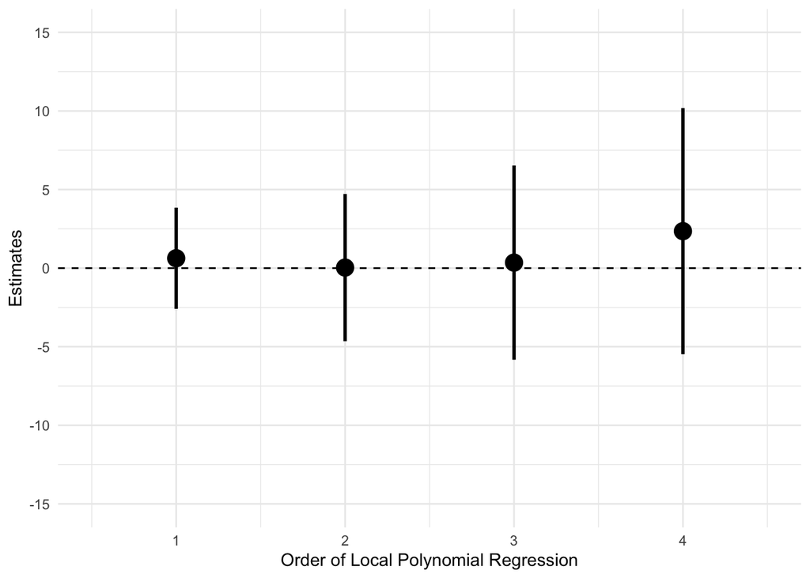

```r
Ariga_Poly_df %>%
    ggplot() +
    geom_hline(yintercept = 0, linetype = 2) +
    geom_pointrange(aes(x = Order, y = Est, ymin = LL, ymax = UL),
                    size = 1) +
    coord_cartesian(ylim = c(-15, 15), xlim = c(0.5, 4.5)) +
    scale_x_continuous(breaks = 1:4, labels = 1:4) +
    scale_y_continuous(breaks = seq(-15, 15, 5),
                       labels = seq(-15, 15, 5)) +
    labs(x = "Order of Local Polynomial Regression",
         y = "Estimates") +
    theme_minimal()
```

4次式回帰では推定値が倍以上高くなるものの、統計的に有意な推定値は得られませんでした。少なくとも、今回のデータからは日本において現職効果はあるとは言えないという結論に至りますね。

他にも、最高次数を変更すると最適バンド幅も変わるでしょう。しかし、ここではバンド幅は固定し、次数のみを変えながらLATEを推定しました。もし、最高次数によって最適バンド幅が変更されることを勘案しながらLATEを推定する際は、`h = ...`引数を消すだけでOKです。

# 閾値周辺における強制変数の操作可能性

RDDの重要な仮定として閾値周辺において強制変数の操作が行われてはいけません。得票率の差を操作することは極めて困難ですので、今回は問題はないと考えられますが、たとえばフランス地方議会選挙のように人口によって制度が変わる場合、特定の選挙制度を採用するために人口を操作することは不可能ではないでしょう。

密度検定は{rdd}の`DCdensity()`で簡単に行うことができます。第一引数は強制変数を、`cutpoint`には閾値を指定します（既定値は0）。

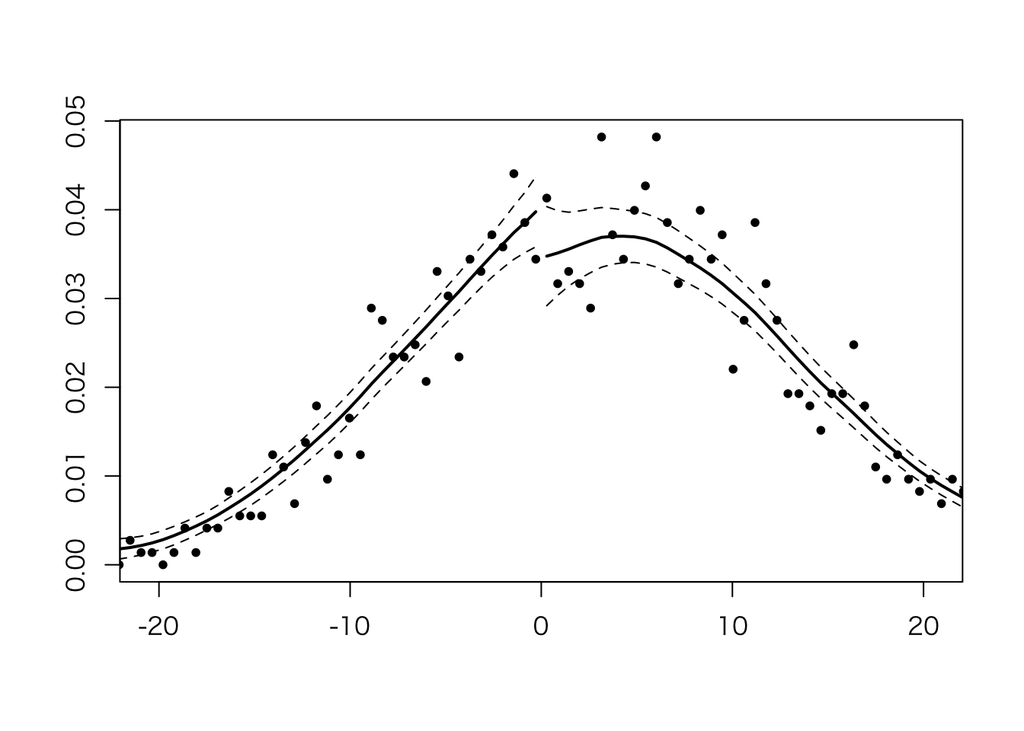

```
## [1] 0.3002424
```

```r
DCdensity(Ariga_df$vm1, cutpoint = 0)
```

図と長さ1のnumeric型ベクトルが出力されますが[^9]、図は密度分布を可視化したものであり、数値は「密度関数は連続している」という帰無仮説に対する*p*値です。これが$\alpha$（通常、$\alpha = 0.05$）を下回る場合、帰無仮説は棄却され、密度関数が断絶していると判断できます。つまり、RDDの仮定を満たしていないことを意味します。

{rdd}の`DCdensity()`以外にも、密度検定専用のパッケージ{rddenstiy}の`rddensity()`を使うことも可能です。検定方法は基本的に同じですが、検定の際に使用するパラメーターや標準誤差計算のアルゴリズムが異なるため、結果はやや異なります。使い方は`X`に強制変数を、`c`に閾値を指定します。他にも十数種類のパラメーターの指定が可能です。

```r
Density_Test <- rddensity(X = Ariga_df$vm1, c = 0)
summary(Density_Test)
```

```
##
## Manipulation testing using local polynomial density estimation.
##
## Number of obs =       1266
## Model =               unrestricted
## Kernel =              triangular
## BW method =           estimated
## VCE method =          jackknife
##
## c = 0                 Left of c           Right of c
## Number of obs         479                 787
## Eff. Number of obs    259                 289
## Order est. (p)        2                   2
## Order bias (q)        3                   3
## BW est. (h)           6.112               6.078
##
## Method                T                   P > |T|
## Robust                -0.818              0.4134
##
##
## P-values of binomial tests (H0: p=0.5).
##
## Window Length / 2          <c     >=c    P>|T|
## 0.215                       7      13    0.2632
## 0.430                      18      24    0.4408
## 0.645                      31      33    0.9007
## 0.860                      40      39    1.0000
## 1.075                      47      51    0.7620
## 1.290                      62      57    0.7140
## 1.505                      70      64    0.6660
## 1.720                      85      77    0.5825
## 1.935                      97      82    0.2954
## 2.150                     106      92    0.3556
```

密度検定の結果（*p*値）は中間当たりにある`# Robust`行の0.4134です。ここでも帰無仮説は棄却されず、強制変数の操作が行われているとは言えません。可視化の際は`rdplotdensity()`関数を使います。第一引数は`rddensity()`から得られたオブジェクト名を指定し、`X`には強制変数を指定します。その他の引数についてはコンソール上で`?rdplotdensity`を入力し、参照してください。

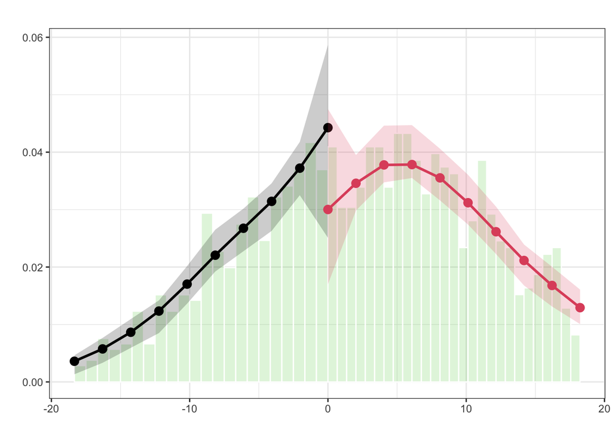

```r
Density_Plot <- rdplotdensity(Density_Test, X = Ariga_df$vm1,
                              type = "both", lwd = 1, pwd = 3, pty = 19)
```

[^1]: もし、自分でバンド幅を指定したい場合、`bw = ...`の引数を加えます。
[^2]: 閾値のデフォルトは0です。もし、閾値が0ではない場合、`cutpoint = ...`の引数を設定します。
[^3]: `rdrobust`パッケージにある`rdplot()`関数を使うことも可能ですが、自分が欲しい図を出すために、指定する引数が多すぎるので、今回は手作りにします。
[^4]: 標準正規分布における下側97.5%の点は`qnorm(0.975)`で計算できます。99%信頼区間が欲しいなら、`qnorm(0.995)`を使います。90%なら`qnorm(0.95)`です。
[^5]: このやり方が正しいかは議論の余地があります。多項式回帰の最高次数によって最適バンド幅は変わるからです。つまり、`Ariga_Poly1`の最適バンド幅は`Ariga_RDD`のそれと同じでしょうが、`Ariga_Poly2`とかではそもそも指定したバンド幅がもはや最適ではなくなります。
[^6]: バイアス修正 (Bias-Corrected)推定値は約3.208で、`$Estimate[2]`で抽出できます。この推定量に関しては[Calonico, Sebastian, Matias D. Cattaneo, and Rocio Titiunik. 2014. “Robust Nonparametric Confidence Intervals for Regression‐Discontinuity Designs.” *Econometrica,* 82: 2295-2326](https://onlinelibrary.wiley.com/doi/abs/10.3982/ECTA11757)を参照して下さい。バイアス修正済みの推定量はデフォルトでは表示されません。
[^7]: 頑健な信頼区間は[-6.567, 12.984]であり、下限は`$ci[3, 1]`で、上限は`$ci[3, 2]`で抽出できます。頑健な標準誤差は`$se[3]`です。ちなみに、バイアス修正標準誤差、信頼区間 (下・上限)は`$se[2]`、`$ci[2, 1]`、`$ci[2, 2]`で抽出します。
[^8]: [McCray, Justin. 2008. “Manipulation of the running variable in the regression discontinuity design: A density test,” *Journal of Econometrics,* 142(2): 698-714.](https://doi.org/10.1016/j.jeconom.2007.05.005)
[^9]: 図が不要なら`plot = FALSE`を指定します。